# AinB Assignment: Group 10

Joaquin Coitino, Wing Yung Ho, Andrea Iglesias Villegas, Jason Kuilan, Lukas Wolff, Dian Yue Josef Zhu

12/14/2016

This report contains interactive elements and has the best user experience if a web browser is used. Printing is possible. However, will not result in an optimal reading experience. The `R` code used to perform these analyses has been provided as supplementary files, and can be viewed in this report using the *Code* buttons to toggle code viewing. All files are available online on Github [here](https://github.com/Josef123456/Analytics_for_Business_Group10.git).

# 1 Introduction

Prior to the start of this analysis, the data provided was cleansed to remove self-moves and separate the matrices provided. These separate datasets were then used for the following sections.

```r
#write.csv(friendship, "friendshipmat.csv")
#write.csv(creat, "creatmat.csv")
#write.csv(implem, "implemmat.csv")
#write.csv(infl, "inflmat.csv")
```

# 2 Regressions

As a starting point, you might like to know how popularity is related to being picked in the other three networks. To assess this, use in-degrees centrality in the Royal Albert hall network as an independent variable in three regressions, one for each of the other teams / networks, where the dependent variable in those regressions will also be in-degrees centrality in those networks. As to estimation, examine the data and select the right estimation method for (e.g., OLS vs. Poisson or negative binomial). Explain your choice of model, submit tables showing your results, and briefly explain what you found. Note: for this task, you are not required to assemble a proper set of controls to rule out alternative explanations; we are only exploring relationships among variables.

**Answer:**

To regress the influence of friendship over individuals’ task-oriented choices, we should apply a negative binomial or Poisson model, as both are applicable to count data, although the former is not affected by overdispersion.

```r
graduation <- read.csv('../Analytics_for_Business_Group10/Question1/peoplepickinganonymisedwoselfvotes.csv', header = TRUE)
centrality <- data.frame(id = graduation$id, friendcent = NA)
friendcols <- c( which(colnames(graduation)=='friend_01'):which(colnames(graduation)=='friend_60'))
advicecols <- c( which(colnames(graduation)=='advice_01'):which(colnames(graduation)=='advice_60'))
creatcols <- c( which(colnames(graduation)=='creat_01'):which(colnames(graduation)=='creat_60'))
inflcols <- c( which(colnames(graduation)=='infl_01'):which(colnames(graduation)=='infl_60'))
implcols <- c( which(colnames(graduation)=='impl_01'):which(colnames(graduation)=='impl_60'))

centrality <- data.frame(id = graduation$id)
centrality$friendship <- colSums(graduation[friendcols])
centrality$advice <- colSums(graduation[advicecols])
centrality$creativity <- colSums(graduation[creatcols])
centrality$influence <- colSums(graduation[inflcols])
centrality$implementation <- colSums(graduation[implcols])
```

In order to make this decision, we tested for overdispersion using odTest:

```r
creat.model <- glm.nb(creativity ~ friendship, data = centrality)
infl.model <- glm.nb(influence ~ friendship, data = centrality)
impl.model <- glm.nb(implementation ~ friendship, data = centrality)

#odTest_creat <- odTest(creat.model)
#odTest_infl <- odTest(infl.model)
#odTest_impl <- odTest(impl.model)
```

*Likelihood ratio test of $H_0$: the restriction of mean = variance in the Poisson model is true*

|  | Creativity Model | Influence Model | Implementation Model |
| --- | --- | --- | --- |
| P-value | 0.004049 | 2.948 x 10^14 | 0.0006068 |

In all the cases, the test provided evidence of the presence of overdispersion at a 95% significance level, allowing us to favour negative binomial models:

```r
stargazer(creat.model, infl.model, impl.model, header = FALSE, table.placement = "H", type = "html", notes.align = "l")
```

|  | *Dependent variable:* |  |  |
| --- | --- | --- | --- |
|  | creativity | influence | implementation |
|  | (1) | (2) | (3) |
| friendship | 0.129*** | 0.099*** | 0.147*** |
|  | (0.022) | (0.033) | (0.024) |
| Constant | 0.883*** | 1.071*** | 0.805*** |
|  | (0.154) | (0.210) | (0.167) |
| Observations | 60 | 60 | 60 |
| Log Likelihood | -140.369 | -156.912 | -148.377 |
| theta | 10.440* (5.479) | 2.592*** (0.727) | 6.801** (3.169) |
| Akaike Inf. Crit. | 284.738 | 317.824 | 300.754 |
| *Note:* | p<0.1; p<0.05; p<0.01 |  |  |

As expected and shown above, the relationship between the friendship factor and the indegree counts seems to be positive and statistically significant across all categories.

# 3 Cosine Similarity

Your leaders should show smart flexibility in picking different people for different tasks. To assess this for each team, treat each person’s picks and non-picks for every person in the class as a binary vector for that team, and use cosine similarity to develop a score that represents individual flexibility of picks across the four networks. Explain the score, and provide a table that ranks all IDs by your score; include the ID, the actual score, and a Z-score for your flexibility score

**Answer:**

The cosine similarity measure was computed to evaluate the flexibility of potential leaders. This method compares the vector of the friendship choices with the vectors for creativity, influence and implementation respectively. From its results, we can derive whether someone was incluned to pick friends in all categories or adjusted their choices by task. High scores might suggest low flexibility and unsuitability for a leadership position.

```r
cosine <- read.csv('../Analytics_for_Business_Group10/Question2/GroupProjectCosineSimilarityExcelTable.csv', header = TRUE)

cosine_Table<- data.frame(cosine$id, round(cosine$Score,6), cosine$Z_score)

DT::datatable(cosine_Table,
              colnames = c("ID", "Score", "Z-Score"),
              caption = "Flexibility Table")
```

|  | ID | Score | Z-Score |
| --- | --- | --- | --- |
| 1 | 1 | 0.141202 | -0.82093182 |
| 2 | 2 | 0 | -1.373426677 |
| 3 | 3 | 0.404796 | 0.21045637 |
| 4 | 4 | 0.166667 | -0.721294987 |
| 5 | 5 | 1 | 2.539362684 |
| 6 | 6 | 0.354707 | 0.014466316 |
| 7 | 7 | 0.166667 | -0.721294987 |
| 8 | 8 | 0.182574 | -0.65905229 |
| 9 | 9 | 0.086066 | -1.036667374 |
| 10 | 10 | 0.467039 | 0.453998553 |

[output cut: 50 more lines]

# 4 Leaders

Using the flexibility analysis in problem 1 and any other criteria you want to introduce, pick the three IDs (individuals) you want to have as leaders for the three teams. Again, explain the logic of your scoring, any qualitative considerations you deem important, and of course, your selections.

**Answer:**

**Page Rank**:

After applying an eigenvector centrality measure resembling a PageRank algorithm for creativity, influence, and implementation, results were included in a Spreadsheet of the followig structure:

- average cosine similarity
- pagerank for respective category
- average pagerank for the successors
- friendship indegree

**Outcome:**

Our choice of leaders was mostly informed by the PageRank measure, indicating the perceived task-specific ability of a person, supported by the previous flexibility score to indicate leadership potential. Additionally, high friendship in-degrees were avoided, as they might constrain the optimality of group member choices. Moreover, the choice to favour large parties informed our choice for the creativity leader.

Our final picks for the leaders are:

- Creativity: 7
- Influence: 21
- Implementation: 19

An alternative combination with the second best leader choices for each task was also examined.

## 4.1 Creativity, Influence, Implementation Table

### 4.1.1 Creativity Table

```r
creattable <- read.csv("../Analytics_for_Business_Group10/Question3/Creativity Table.csv")
creat_table <- data.frame(creattable$id, round(creattable$Creativity.Page.Rank,6), round(creattable$Cosine.similarity,6), round(creattable$Overall.Average.Page.Rank.of.Successors,6), round(creattable$Average.Creativity.Page.Rank.Successors,6), round(creattable$Frienship.indegree,6))


DT::datatable(creat_table,
              colnames = c("ID", "Creativity Page Rank", "Cosine similarity",
                           "Overall Average Page Rank of Successors",
                           "Average Creativity Page Rank Successors", "Frienship indegree"),
              caption = "Creativity Table")
```

|  | ID | Creativity Page Rank | Cosine similarity | Overall Average Page Rank of Successors | Average Creativity Page Rank Successors | Frienship indegree |
| --- | --- | --- | --- | --- | --- | --- |
| 1 | 1 | 0.018136 | 0.141202 | 0.042981 | 0.031033 | 3 |
| 2 | 2 | 0.004749 | 0 | 0.026019 | 0.023464 | 7 |
| 3 | 3 | 0.004342 | 0.404796 | 0.026269 | 0.014597 | 3 |
| 4 | 4 | 0.003879 | 0.166667 | 0.013402 | 0.008291 | 2 |
| 5 | 5 | 0.004688 | 1 | 0.013789 | 0.009857 | 5 |
| 6 | 6 | 0.020871 | 0.354707 | 0.02453 | 0.033414 | 6 |
| 7 | 7 | 0.06751 | 0.166667 | 0.04056 | 0.034789 | 8 |
| 8 | 8 | 0.009233 | 0.182574 | 0.037005 | 0.038585 | 1 |
| 9 | 9 | 0.005357 | 0.086066 | 0.040588 | 0.021341 | 5 |
| 10 | 10 | 0.005292 | 0.467039 | 0.035325 | 0.047114 | 4 |

[output cut: 50 more lines]

### 4.1.2 Influence table

```r
infltable <- read.csv("../Analytics_for_Business_Group10/Question3/Influence Table.csv")
infl_table <- data.frame(infltable$id, round(infltable$Influence.Page.Rank,6), round(infltable$Cosine.similarity,6), round(infltable$Overall.Average.Page.Rank.of.Successors,6), round(infltable$Average.Influence.Page.Rank.Successors,6), round(infltable$Frienship.indegree,6))


DT::datatable(infl_table,
              colnames = c("ID", "Influence Page Rank", "Cosine similarity",
                           "Overall Average Page Rank of Successors",
                           "Average Influence Page Rank Successors", "Frienship indegree"),
              caption = "Influence Table")
```

|  | ID | Influence Page Rank | Cosine similarity | Overall Average Page Rank of Successors | Average Influence Page Rank Successors | Frienship indegree |
| --- | --- | --- | --- | --- | --- | --- |
| 1 | 1 | 0.039295 | 0.141202 | 0.042981 | 0.055027 | 3 |
| 2 | 2 | 0.02212 | 0 | 0.026019 | 0.035941 | 7 |
| 3 | 3 | 0.002746 | 0.404796 | 0.026269 | 0.031535 | 3 |
| 4 | 4 | 0.003472 | 0.166667 | 0.013402 | 0.021425 | 2 |
| 5 | 5 | 0.011507 | 1 | 0.013789 | 0.014412 | 5 |
| 6 | 6 | 0.019315 | 0.354707 | 0.02453 | 0.022298 | 6 |
| 7 | 7 | 0.051554 | 0.166667 | 0.04056 | 0.046585 | 8 |
| 8 | 8 | 0.008807 | 0.182574 | 0.037005 | 0.042144 | 1 |
| 9 | 9 | 0.005287 | 0.086066 | 0.040588 | 0.057492 | 5 |
| 10 | 10 | 0.010597 | 0.467039 | 0.035325 | 0.035824 | 4 |

[output cut: 50 more lines]

### 4.1.3 Implementation table

```r
impltable <- read.csv("../Analytics_for_Business_Group10/Question3/Implementation Table.csv")
impl_table <- data.frame(impltable$id, round(impltable$Implementation.Page.Rank,6), round(impltable$Cosine.similarity,6), round(impltable$Overall.Average.Page.Rank.of.Successors,6), round(impltable$Average.Implementation.Page.Rank.Successors,6), round(impltable$Frienship.indegree,6))


DT::datatable(impl_table,
              colnames = c("ID", "Impl Page Rank", "Cosine similarity",
                           "Overall Average Page Rank of Successors",
                           "Average Impl Page Rank Successors", "Frienship indegree"),
              caption = "Implementation Table")
```

|  | ID | Impl Page Rank | Cosine similarity | Overall Average Page Rank of Successors | Average Impl Page Rank Successors | Frienship indegree |
| --- | --- | --- | --- | --- | --- | --- |
| 1 | 1 | 0.04076 | 0.141202 | 0.042981 | 0.042883 | 3 |
| 2 | 2 | 0.021465 | 0 | 0.026019 | 0.018653 | 7 |
| 3 | 3 | 0.002832 | 0.404796 | 0.026269 | 0.032674 | 3 |
| 4 | 4 | 0.003234 | 0.166667 | 0.013402 | 0.010489 | 2 |
| 5 | 5 | 0.0096 | 1 | 0.013789 | 0.0171 | 5 |
| 6 | 6 | 0.016633 | 0.354707 | 0.02453 | 0.017878 | 6 |
| 7 | 7 | 0.042871 | 0.166667 | 0.04056 | 0.040308 | 8 |
| 8 | 8 | 0.024239 | 0.182574 | 0.037005 | 0.030287 | 1 |
| 9 | 9 | 0.005377 | 0.086066 | 0.040588 | 0.04293 | 5 |
| 10 | 10 | 0.009846 | 0.467039 | 0.035325 | 0.023037 | 4 |

[output cut: 50 more lines]

## 4.2 Approach:

*Below we provided our code to justify our PageRank calulations:*

Code snippet for friendship:

```r
friendship <- graduation[,c( which(colnames(graduation)=='friend_01'):which(colnames(graduation)=='friend_60'))]
mat_friendship <- data.matrix(friendship, rownames.force = NA)

friendship.g <- graph.adjacency(mat_friendship, mode = "directed", weighted = NULL, diag = TRUE, add.colnames = NULL, add.rownames = NA)

## Ranking advice by a page rank
page.ranking.friendship <- page.rank(friendship.g, vids=V(friendship.g))

## Sorting the page rank on highest value based on id with top 3
sort.friendship <- sort.list(page.ranking.friendship$vector, decreasing = TRUE)
top3.friendship <- sort.friendship[1:10]
sorted.f <- page.ranking.friendship$vector[top3.friendship]

#pander(sorted.f,digits = 2)
```

Code snippet for advice:

```r
advice <- graduation[,c( which(colnames(graduation)=='advice_01'):which(colnames(graduation)=='advice_60'))]
mat_advice <- data.matrix(advice, rownames.force = NA)

advice.g <- graph.adjacency(mat_advice, mode = "directed", weighted = NULL, diag = TRUE, add.colnames = NULL, add.rownames = NA)

## Ranking advice by a page rank
page.ranking.advice <- page.rank(advice.g, vids=V(advice.g))

## Sorting the page rank on highest value based on id with top 3
sort.advice <- sort.list(page.ranking.advice$vector, decreasing = TRUE)
top3.advice <- sort.advice[1:10]
sorted.a <- page.ranking.advice$vector[top3.advice]

#pander(sorted.a,digits = 2)
```

Code snippet for creativity:

```r
creat <- graduation[,c( which(colnames(graduation)=='creat_01'):which(colnames(graduation)=='creat_60'))]
mat_creat <- data.matrix(creat, rownames.force = NA)

creat.g <- graph.adjacency(mat_creat, mode = "directed", weighted = NULL, diag = TRUE, add.colnames = NULL, add.rownames = NA)
## Ranking advice by a page rank
page.ranking.creat <- page.rank(creat.g, vids=V(creat.g))
creat.ranked <- lapply(page.ranking.creat, function(x) x[which.max(x)])

#write.csv(page.ranking.creat$vector, file = "CreativityPageRank.csv")

## Sorting the page rank on highest value based on id
sort.creat <- sort.list(page.ranking.creat$vector, decreasing = TRUE)
top3.creat <- sort.creat[1:10]
sorted.c <- page.ranking.creat$vector[top3.creat]

#pander(sorted.c,digits = 2)
```

Code snippet for influence:

```r
infl <- graduation[,c( which(colnames(graduation)=='infl_01'):which(colnames(graduation)=='infl_60'))]
mat_infl <- data.matrix(infl, rownames.force = NA)

infl.g <- graph.adjacency(mat_infl, mode = "directed", weighted = NULL, diag = TRUE, add.colnames = NULL, add.rownames = NA)

## Ranking infl by a page rank
page.ranking.infl <- page.rank(infl.g, vids=V(infl.g))
infl.ranked <- lapply(page.ranking.infl, function(x) x[which.max(x)])

#write.csv(page.ranking.infl$vector, file = "InfluencePageRank.csv")

## Sorting the page rank on highest value based on id
sort.infl <- sort.list(page.ranking.infl$vector, decreasing = TRUE)
top3.infl <- sort.infl[1:10]
sorted.in <- page.ranking.infl$vector[top3.infl]

#pander(sorted.in,digits = 2)
```

Code snippet for implementation:

```r
impl <- graduation[,c( which(colnames(graduation)=='impl_01'):which(colnames(graduation)=='impl_60'))]
mat_impl <- data.matrix(impl, rownames.force = NA)

impl.g <- graph.adjacency(mat_impl, mode = "directed", weighted = NULL, diag = TRUE, add.colnames = NULL, add.rownames = NA)

## Ranking impl by a page rank
page.ranking.impl <- page.rank(impl.g, vids=V(impl.g))
impl.ranked <- lapply(page.ranking.impl, function(x) x[which.max(x)])

#write.csv(page.ranking.impl$vector, file = "ImplementationPageRank.csv")

## Sorting the page rank on highest value based on id
sort.impl <- sort.list(page.ranking.impl$vector, decreasing = TRUE)
top3.impl <- sort.impl[1:10]
sorted.impl <- page.ranking.impl$vector[top3.impl]

#pander(sorted.impl,digits = 2)
```

*The table below contains the 10 people with the highest PageRank score for every task category, and friendship.*

Top Ten: Page Rank Summary

| Ranking | Friendship | Creativity | Influence | Implementation |
| --- | --- | --- | --- | --- |
| 1 | 33 | 7 | 21 | 33 |
| 2 | 51 | 33 | 19 | 21 |
| 3 | 14 | 21 | 7 | 19 |
| 4 | 21 | 19 | 30 | 30 |
| 5 | 46 | 35 | 20 | 7 |
| 6 | 56 | 50 | 1 | 22 |
| 7 | 29 | 20 | 22 | 1 |
| 8 | 28 | 46 | 52 | 52 |
| 9 | 12 | 25 | 34 | 25 |
| 10 | 19 | 48 | 56 | 29 |

The python code can be found [here](http://pastebin.com/TygYBfkX) and is also available in the appendix section.

# 5 ID Rankings

*Finally, produce three tables that rank IDs by a networkspecific constructed measure of value, which is some kind of cost-benefit ratio. Explain the logic of your measure. To get you started, recall that the “cost” of each pick is the in-degrees score in the Royal Albert Hall network, so that is your denominator.*

**Answer:**

Having chosen the PageRank measure to evaluate each individual’s perceived suitability to a specific task, our calculated cost-benefit ratio is this PageRank score (for each category) divided by their friendship in-degree. Three tables were then created containing the IDs, PageRank scores, friendship in-degrees and our cost-benefit ratio results.

## 5.1 Cost-Benefit Ratio

### 5.1.1 Creativity

```r
creattable <- read.csv("../Analytics_for_Business_Group10/Question4/Creativity Table.csv")
creat_table <- data.frame(creattable$id, round(creattable$Creativity.Page.Rank,6), round(creattable$Frienship.indegree,6), round(creattable$Creativity.Ratio,6))


DT::datatable(creat_table,
              colnames = c("ID", "Creativity Page Rank","Frienship indegree","Creativity: Cost-Benefit Ratio"),
              caption = "Creativity: Cost-Benefit Ratio")
```

|  | ID | Creativity Page Rank | Frienship indegree | Creativity: Cost-Benefit Ratio |
| --- | --- | --- | --- | --- |
| 1 | 1 | 0.018136 | 3 | 0.006045 |
| 2 | 2 | 0.004749 | 7 | 0.000678 |
| 3 | 3 | 0.004342 | 3 | 0.001447 |
| 4 | 4 | 0.003879 | 2 | 0.00194 |
| 5 | 5 | 0.004688 | 5 | 0.000938 |
| 6 | 6 | 0.020871 | 6 | 0.003479 |
| 7 | 7 | 0.06751 | 8 | 0.008439 |
| 8 | 8 | 0.009233 | 1 | 0.009233 |
| 9 | 9 | 0.005357 | 5 | 0.001071 |
| 10 | 10 | 0.005292 | 4 | 0.001323 |

[output cut: 50 more lines]

### 5.1.2 Influence

```r
infltable <- read.csv("../Analytics_for_Business_Group10/Question4/Influence Table.csv")
infl_table <- data.frame(infltable$id, round(infltable$Influence.Page.Rank,6), round(infltable$Frienship.indegree,6), round(infltable$Influence.Ratio,6))


DT::datatable(infl_table,
              colnames = c("ID", "Influence Page Rank","Frienship indegree","Influence: Cost-Benefit Ratio"),
              caption = "Influence: Cost-Benefit Ratio")
```

|  | ID | Influence Page Rank | Frienship indegree | Influence: Cost-Benefit Ratio |
| --- | --- | --- | --- | --- |
| 1 | 1 | 0.039295 | 3 | 0.013098 |
| 2 | 2 | 0.02212 | 7 | 0.00316 |
| 3 | 3 | 0.002746 | 3 | 0.000915 |
| 4 | 4 | 0.003472 | 2 | 0.001736 |
| 5 | 5 | 0.011507 | 5 | 0.002301 |
| 6 | 6 | 0.019315 | 6 | 0.003219 |
| 7 | 7 | 0.051554 | 8 | 0.006444 |
| 8 | 8 | 0.008807 | 1 | 0.008807 |
| 9 | 9 | 0.005287 | 5 | 0.001057 |
| 10 | 10 | 0.010597 | 4 | 0.002649 |

[output cut: 50 more lines]

### 5.1.3 Implementation

```r
impltable <- read.csv("../Analytics_for_Business_Group10/Question4/Implementation Table.csv")
impl_table <- data.frame(impltable$id, round(impltable$Implementation.Page.Rank,6), round(impltable$Frienship.indegree,6), round(impltable$Implementation.Ratio,6))


DT::datatable(impl_table,
              colnames = c("ID", "Impl Page Rank", "Frienship indegree","Impl.: Cost-Benefit Ratio"),
              caption = "Implementation: Cost-Benefit Ratio")
```

|  | ID | Impl Page Rank | Frienship indegree | Impl.: Cost-Benefit Ratio |
| --- | --- | --- | --- | --- |
| 1 | 1 | 0.04076 | 3 | 0.013587 |
| 2 | 2 | 0.021465 | 7 | 0.003066 |
| 3 | 3 | 0.002832 | 3 | 0.000944 |
| 4 | 4 | 0.003234 | 2 | 0.001617 |
| 5 | 5 | 0.0096 | 5 | 0.00192 |
| 6 | 6 | 0.016633 | 6 | 0.002772 |
| 7 | 7 | 0.042871 | 8 | 0.005359 |
| 8 | 8 | 0.024239 | 1 | 0.024239 |
| 9 | 9 | 0.005377 | 5 | 0.001075 |
| 10 | 10 | 0.009846 | 4 | 0.002461 |

[output cut: 50 more lines]

# 6 Conclusion

After running the optimization model in **Ampl** to yield the best groups for our chosen leaders, the social dynamics of the cohort, which cannot be captured in the model, were explored. A community detection algorithm, Infomap, found a realistic ‘best partition’ for the class friendship network, which allowed to visualise group members’ distribution across it. In the graph below, the class is divided into 4 communities (The Ampl code can be found on [Github](https://github.com/Josef123456/Analytics_for_Business_Group10.git) and in the appendix section):

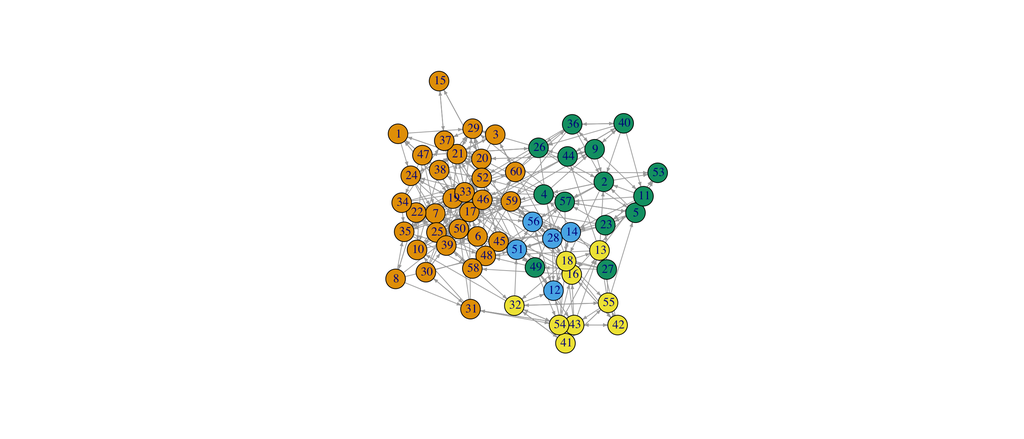

## 6.1 Evaluation

### 6.1.1 Original Optimisation Model

### 6.1.2 Option 1

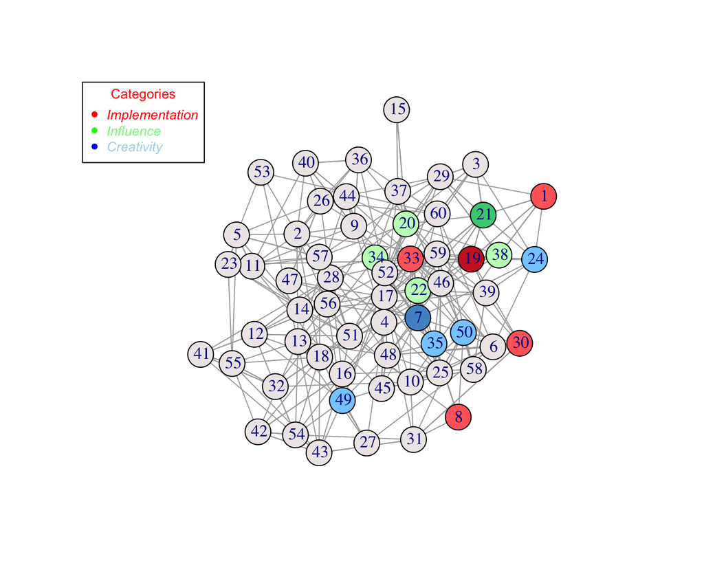

### 6.1.3 Option 2

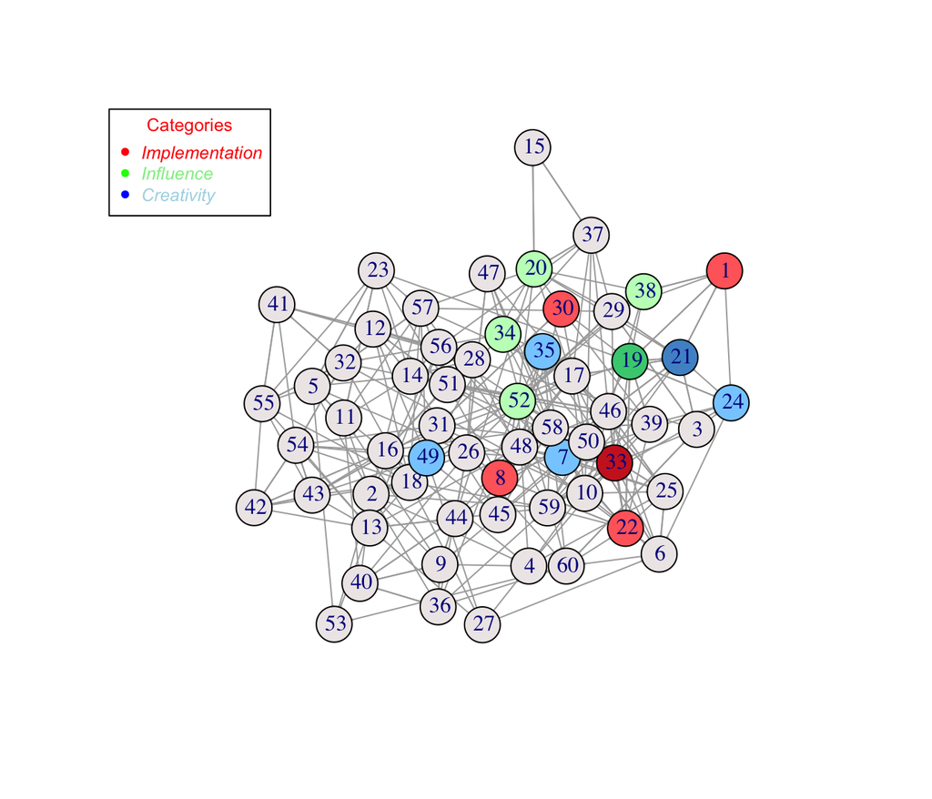

According to this partition, only one of the team members for all categories comes from a different community than the rest. In the case of the implementation team, this might suggest that team members are close enough to work together effectively and cohesively. However, for the creativity and influence teams, members should preferably be distributed across the network to better represent everyone’s interests.

Consequently, a constraint was added to the model allowing no more than two members of the team for influence and creativity to belong to the same community. While the cumulative creativity PageRank for the new creativity team was significantly lower, the difference for the new influence team was not as large. Therefore, only the new influence group provided by this revisited model was included in the final model choice to factor in the benefit of cross-cluster representativeness.

### 6.1.4 Final Option

Further to this analysis, the plot below depicts our final choices for the groups:

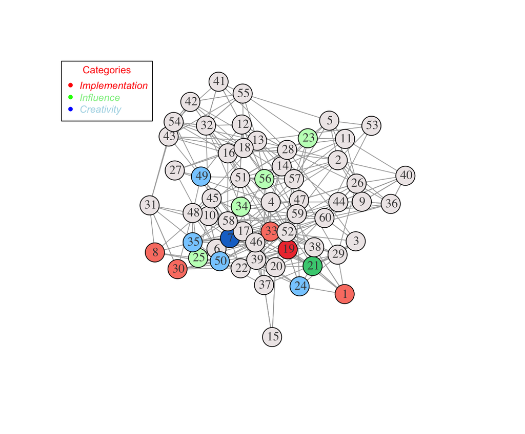

# 7 Bonus

*Revisiting question 2, cosine similarity is but one method of assessing flexibility. If you allow yourself to think beyond using that technique to compare the similarity of two vectors of picks (0s and 1s), what other more creative method might you devise? How does it compare to cosine similarity? If it is different, can you provide a qualitative description of what your measure captures that is not in cosine similarity? Is it better?*

**Answer:**

Before we can decide if another method would be better suited we must first explore what cosine similarity (CS) is, what it tells us, and why this is important. CS takes the angle between two vectors and returns a value between 0 and 1 depending on the angle between the two vectors. Vectors with a small angle between them will give us a value close to 1, while vectors with a large angle will give values close to 0. Someone who has low CS shows they choose different people than their friend circle, likewise, someone with a high CS made their choices like their friend circle. While most people are comfortable working within their friend group, some see the benefit of working outside their circle to get different outlooks on various situations.

While CS is good measure of someone’s adaptability, we do not agree that it is the best in our case. After exploring other options, we think Jaccard similarity (JS) would be the appropriate method to use. JS divides the intersection of a set by the union of the same set. This method accounts for both the magnitude and angle between vectors. The values of JS are like the CS method, with values ranging between 0 (for differing vectors) and 1 (for similar vectors).

As in our case, not all people have the same number of choices, we think the magnitude of the vector should be integrated as well into our calculations.

# 8 Appendix:

### 8.0.1 Question 3: Leaders

```
import numpy as np
import pandas as pd
import networkx as nx
import pylab as pl


friends = pd.read_csv("/Users/joaquincoitino/Desktop/peoplepickinganonymisedwoselfvotes.csv", header=0, index_col=0)

cosine_similarity = pd.read_csv("/Users/joaquincoitino/Desktop/GroupProjectCosineSimilarityExcelTable.csv", header=0, index_col=0)


def mean(numbers):
   return float(sum(numbers)) / max(len(numbers), 1)


### Average PageRank for Creativity:

creat_pagerank = pd.read_csv("/Users/joaquincoitino/Desktop/CreativityPageRank.csv", usecols = ['x'])

creat_adj_matrix = friends.loc[:,'creat_01':'creat_60'].as_matrix()

creat_graph = nx.from_numpy_matrix(creat_adj_matrix, create_using = nx.DiGraph())

creat_pr_successors = []

for i in creat_graph.nodes_iter():
    list_pr =[]

    for j in creat_graph.successors(i):
        list_pr.append(creat_pagerank.loc[j,'x'])
    creat_pr_successors.append(mean(list_pr))


### Average PageRank for Influence:

infl_pagerank = pd.read_csv("/Users/joaquincoitino/Desktop/InfluencePageRank.csv", usecols = ['x'])

infl_adj_matrix = friends.loc[:,'infl_01':'infl_60'].as_matrix()

infl_graph = nx.from_numpy_matrix(infl_adj_matrix, create_using = nx.DiGraph())
```

[output cut: 51 more lines]

```

cosine = cosine_similarity.loc[:,'Score'].tolist()

pr_creat = creat_pagerank.loc[:,'x'].tolist()
pr_infl = infl_pagerank.loc[:,'x'].tolist()
pr_impl = impl_pagerank.loc[:,'x'].tolist()

creat_dataframe = pd.DataFrame.from_items([('id', list(range(1,61))), ('Creativity Page Rank', pr_creat), ('Cosine similarity', cosine), ('Overall Average Page Rank of Successors', avg_pagerank_succe), ('Average Creativity Page Rank Successors', creat_pr_successors), ('Frienship indegree', list_f_in…
creat_dataframe.to_csv('Creativity Table.csv', index = False)

infl_dataframe = pd.DataFrame.from_items([('id', list(range(1,61))), ('Influence Page Rank', pr_infl), ('Cosine similarity', cosine), ('Overall Average Page Rank of Successors', avg_pagerank_succe), ('Average Influence Page Rank Successors', infl_pr_successors), ('Frienship indegree', list_f_indegre…
infl_dataframe.to_csv('Influence Table.csv', index = False)

impl_dataframe = pd.DataFrame.from_items([('id', list(range(1,61))), ('Implementation Page Rank', pr_impl), ('Cosine similarity', cosine), ('Overall Average Page Rank of Successors', avg_pagerank_succe), ('Average Implementation Page Rank Successors', impl_pr_successors), ('Frienship indegree', list…
impl_dataframe.to_csv('Implementation Table.csv', index = False)
```

### 8.0.2 Optimization Model AMPL

**maxpagerank.mod:**

```
set id ordered ;
param create_pr {id};
param imp_pr {id};
param inf_pr {id};
param friendship_indegree {id};

data allpagerank.dat;
param N := 3;

var x {i in id , 1.. N} binary;

maximize pr: sum {i in id} (x[i,1]*create_pr[i]+ x[i,2]*inf_pr[i] +x[i,3]*imp_pr[i]);

subject to create_friendship: sum {i in id}  (x[i,1]*friendship_indegree[i]) <= 30;
subject to inf_friendship: sum {i in id}  (x[i,2]*friendship_indegree[i]) <= 30;
subject to imp_friendship: sum {i in id}  (x[i,3]*friendship_indegree[i]) <= 30;
subject to create_4members:  sum {i in id} (x[i,1]) = 5;
subject to inf_4members:  sum {i in id} (x[i,2]) = 5;
subject to imp_4members:  sum {i in id} (x[i,3]) = 5;
subject to picked_once {i in id}: x[i,1] + x[i,2] + x[i,3] <= 1;
subject to create_leader: x[7,1] = 1;
subject to inf_leader: x[21,2] = 1;
subject to imp_leader: x[19,3] = 1;
```

**maxpagerank_withcomm.mod** (With community):

```
set id ordered ;
param create_pr {id};
param imp_pr {id};
param inf_pr {id};
param friendship_indegree {id};

data allpagerank.dat;
param N := 3;

var x {i in id , 1.. N} binary;

maximize pr: sum {i in id} (x[i,1]*create_pr[i]+ x[i,2]*inf_pr[i] +x[i,3]*imp_pr[i]);

subject to create_friendship: sum {i in id}  (x[i,1]*friendship_indegree[i]) <= 30;
subject to inf_friendship: sum {i in id}  (x[i,2]*friendship_indegree[i]) <= 30;
subject to imp_friendship: sum {i in id}  (x[i,3]*friendship_indegree[i]) <= 30;
subject to create_4members:  sum {i in id} (x[i,1]) = 5;
subject to inf_4members:  sum {i in id} (x[i,2]) = 5;
subject to imp_4members:  sum {i in id} (x[i,3]) = 5;
subject to picked_once {i in id}: x[i,1] + x[i,2] + x[i,3] <= 1;
subject to create_leader: x[7,1] = 1;
subject to inf_leader: x[21,2] = 1;
subject to imp_leader: x[19,3] = 1;
subject to creat_community1: x[51,1]+ x[56,1]+x[28,1]+x[14,1]+ x[12,1] <=2;
subject to creat_community2: x[32,1]+ x[54,1]+x[43,1]+x[41,1]+ x[42,1]+x[55,1]+x[16,1]+x[18,1]+x[13,1] <=2;
subject to creat_community3: x[49,1]+ x[27,1]+x[23,1]+x[57,1]+ x[4,1]+x[5,1]+x[11,1]+x[2,1]+x[44,1]+x[26,1]+x[36,1]+x[9,1]+x[40,1]+x[53,1]<=2;
subject to creat_community4: x[15,1]+ x[1,1]+x[29,1]+x[3,1]+ x[37,1]+x[21,1]+x[20,1]+x[60,1]+x[47,1]+x[38,1]+x[52,1]+x[33,1]+x[46,1]+x[59,1] +x[24,1]+x[19,1]+x[17,1]+x[34,1]+x[22,1] +x[7,1]+x[50,1]+x[6,1]+x[45,1]+x[35,1] +x[10,1]+x[30,1]+x[8,1]+x[31,1]+x[58,1] + x[48,1] + x[39,1]<=2;
subject to inf_community1: x[51,2]+ x[56,2]+x[28,2]+x[14,2]+ x[12,2] <=2;
subject to inf_community2: x[32,2]+ x[54,2]+x[43,2]+x[41,2]+ x[42,2]+x[55,2]+x[16,2]+x[18,2]+x[13,2] <=2;
subject to inf_community3: x[49,2]+ x[27,2]+x[23,2]+x[57,2]+ x[4,2]+x[5,2]+x[11,2]+x[2,2]+x[44,2]+x[26,2]+x[36,2]+x[9,2]+x[40,2]+x[53,2]<=2;
subject to inf_community4: x[15,2]+ x[1,2]+x[29,2]+x[3,2]+ x[37,2]+x[21,2]+x[20,2]+x[60,2]+x[47,2]+x[38,2]+x[52,2]+x[33,2]+x[46,2]+x[59,2] +x[24,2]+x[19,2]+x[17,2]+x[34,2]+x[22,2] +x[7,2]+x[50,2]+x[6,2]+x[45,2]+x[35,2] +x[10,2]+x[30,2]+x[8,2]+x[31,2]+x[58,2] + x[48,2] + x[39,2]<=2;
```